# Análise da PNS – Diabetes e Fatores Associados

Welington Nogueira

2025-12-13

## 1 Introdução

Este relatório apresenta a análise exploratória e inferencial dos dados da Pesquisa Nacional de Saúde (PNS), com foco na associação entre diabetes autorreferida e variáveis sociodemográficas, econômicas, regionais e antropométricas.

Também é aplicado um procedimento de imputação de valores ausentes via aprendizado de máquina, utilizando árvores de decisão.

## 2 Leitura dos Dados

```r
banco_pns <- read_dta("PNSFINAL.dta")
banco_ina <- read_dta("INAPOFFINAL.dta")
```

## 3 Analise de dados faltantes (Pré-Tratamento)

```r
missing_pre <- banco_pns %>%
summarise(across(everything(), ~ sum(is.na(.)))) %>%
pivot_longer(
cols = everything(),
names_to = "variavel",
values_to = "n_missing"
) %>%
mutate(
perc_missing = round(100 * n_missing / nrow(banco_pns), 1)
) %>%
arrange(desc(perc_missing))

knitr::kable(
missing_pre,
caption = "Valores ausentes por variável – banco original PNS"
)
```

Valores ausentes por variável – banco original PNS

| variavel | n_missing | perc_missing |
| --- | --- | --- |
| diabetes_auto | 152330 | 74.1 |
| circunf_cintura | 146144 | 71.1 |
| diabetes_exame | 145344 | 70.7 |
| faixa_etaria | 59966 | 29.2 |
| renda_pct | 224 | 0.1 |
| ID_pns | 0 | 0.0 |
| sexo | 0 | 0.0 |
| idade_anos | 0 | 0.0 |
| cor_da_pele | 0 | 0.0 |
| peso_morador_selec | 0 | 0.0 |
| GrandesRegioes | 0 | 0.0 |

## 4 Detecção de Outliers (Pré-Categorização)

```r
detectar_outliers <- function(x){
x <- x[is.finite(x)]
q1 <- quantile(x, 0.25)
q3 <- quantile(x, 0.75)
iqr <- q3 - q1
sum(x < (q1 - 1.5 * iqr) | x > (q3 + 1.5 * iqr))
}

outliers_numericos <- tibble(
variavel = c(
"Idade (anos)",
"Renda per capita (R$)",
"Peso do morador",
"Circunferência da cintura (cm)"
),
n_outliers = c(
detectar_outliers(banco_pns$idade_anos),
detectar_outliers(banco_pns$renda_pct),
detectar_outliers(banco_pns$peso_morador_selec),
detectar_outliers(banco_pns$circunf_cintura)
)
)

knitr::kable(
outliers_numericos,
caption = "Outliers detectados em variáveis contínuas (método IQR)"
)
```

Outliers detectados em variáveis contínuas (método IQR)

| variavel | n_outliers |
| --- | --- |
| Idade (anos) | 110 |
| Renda per capita (R$) | 19532 |
| Peso do morador | 16848 |
| Circunferência da cintura (cm) | 510 |

## 5 Seleção e Tratamento das Variáveis - PNS

```r
d_pns <- banco_pns %>%
select(
sexo, idade_anos, faixa_etaria, cor_da_pele,
renda_pct, peso_morador_selec,
GrandesRegioes, circunf_cintura, diabetes_auto
) %>%
filter(idade_anos >= 18) %>%
filter(renda_pct > 100, renda_pct < 15000) %>%
mutate(
faixa_etaria = case_when(
idade_anos >= 18 & idade_anos <= 29 ~ "1",
idade_anos >= 30 & idade_anos <= 49 ~ "2",
idade_anos >= 50 & idade_anos <= 69 ~ "3",
idade_anos >= 70 & idade_anos <= 89 ~ "4",
idade_anos >= 90 ~ "5"
),
renda_pct = case_when(
renda_pct <= 1088  ~ "1",
renda_pct <= 2403  ~ "2",
renda_pct <= 3890  ~ "3",
renda_pct <= 7017  ~ "4",
renda_pct <= 12683 ~ "5",
renda_pct > 12683  ~ "6"
),
circunf_cintura = case_when(
circunf_cintura < 85 ~ "1",
circunf_cintura >= 85 & circunf_cintura <= 90 ~ "2",
circunf_cintura > 90 & circunf_cintura <= 100 ~ "3",
circunf_cintura > 100 ~ "4"
),
diabetes_auto = case_when(
diabetes_auto %in% c("1","2") ~ "1",
diabetes_auto == "3" ~ "2"
)
)
```

## 6 Imputação de Valores Ausentes via Machine Learning

```r
vars_modelo <- c(
"sexo","faixa_etaria","cor_da_pele",
"renda_pct","GrandesRegioes",
"circunf_cintura","diabetes_auto"
)

dados_modelo <- d_pns[, vars_modelo]
dados_treino <- dados_modelo[complete.cases(dados_modelo), ]

ctrl <- trainControl(method = "cv", number = 5)

modelo_cc <- train(
circunf_cintura ~ .,
data = dados_treino,
method = "rpart",
trControl = ctrl
)

modelo_da <- train(
diabetes_auto ~ .,
data = dados_treino,
method = "rpart",
trControl = ctrl
)

idx_cc <- is.na(d_pns$circunf_cintura)
idx_da <- is.na(d_pns$diabetes_auto)

d_pns$circunf_cintura[idx_cc] <-
predict(modelo_cc, d_pns[idx_cc, vars_modelo[-6]])

d_pns$diabetes_auto[idx_da] <-
predict(modelo_da, d_pns[idx_da, vars_modelo[-7]])
```

## 7 Labels das Variáveis e Categorias - PNS

```r
var_label(d_pns) <- list(
sexo = "Sexo do morador selecionado",
idade_anos = "Idade em anos",
faixa_etaria = "Faixa etária",
cor_da_pele = "Cor ou raça autorreferida",
renda_pct = "Renda domiciliar per capita",
peso_morador_selec = "Peso do morador selecionado",
circunf_cintura = "Circunferência da cintura",
diabetes_auto = "Diabetes autorreferido",
GrandesRegioes = "Grandes regiões"
)

d_pns <- d_pns %>%
mutate(
sexo = factor(sexo, levels = c("1","2"),
labels = c("Masculino","Feminino")),
cor_da_pele = factor(cor_da_pele,
levels = c("1","2","3","4","5","9"),
labels = c("Branca","Preta","Amarela",
"Parda","Indígena","Ignorado")),
faixa_etaria = factor(faixa_etaria,
levels = c("1","2","3","4","5"),
labels = c("18–29","30–49","50–69","70–89","90+")),
diabetes_auto = factor(diabetes_auto,
levels = c("1","2"),
labels = c("Sim","Não")),
GrandesRegioes = factor(GrandesRegioes,
levels = c("1","2","3","4","5"),
labels = c("Norte","Nordeste",
"Sudeste","Sul","Centro-Oeste"))
)
```

## 8 Testes de Independência (Qui-quadrado)

📌 Observações preliminares importantes

Todos os testes Qui-quadrado apresentaram p-valor < 0,001, o que é esperado em bases muito grandes como a PNS.

Portanto, a significância estatística deve ser interpretada junto ao tamanho do efeito (V de Cramer), que é o critério principal aqui.

O V de Cramer varia de 0 a 1:

0,01 → efeito desprezível 0,10 → efeito fraco 0,30 → efeito moderado ≥0,50 → efeito forte

```r
## --------------------------------------------------
## TESTES DE INDEPENDÊNCIA (QUI-QUADRADO + V DE CRAMER)
## --------------------------------------------------

calcular_cramerV <- function(x, y){
  tab <- table(x, y)
  chi <- suppressWarnings(chisq.test(tab, correct = FALSE))
  n <- sum(tab)
  k <- min(nrow(tab), ncol(tab))
  V <- sqrt(chi$statistic / (n * (k - 1)))
  return(as.numeric(V))
}

variaveis <- c(
  "sexo", "faixa_etaria", "cor_da_pele",
  "renda_pct", "GrandesRegioes", "circunf_cintura"
)

for(v in variaveis){

  cat("\n==============================\n")
  cat("Variável:", v, "\n")
  cat("==============================\n")

  tab <- table(d_pns[[v]], d_pns$diabetes_auto)

  teste_chi <- suppressWarnings(
    chisq.test(tab, correct = FALSE)
  )

  print(teste_chi)

  cat("\nV de Cramer:\n")
  print(calcular_cramerV(d_pns[[v]], d_pns$diabetes_auto))
}
```

```
##
## ==============================
## Variável: sexo
## ==============================
##
##  Pearson's Chi-squared test
##
## data:  tab
## X-squared = 291.42, df = 1, p-value < 0.00000000000000022
##
##
## V de Cramer:
## [1] 0.04567133
##
## ==============================
## Variável: faixa_etaria
## ==============================
##
##  Pearson's Chi-squared test
##
## data:  tab
## X-squared = 3672.7, df = 4, p-value < 0.00000000000000022
##
##
## V de Cramer:
## [1] 0.1621346
##
## ==============================
## Variável: cor_da_pele
## ==============================
##
##  Pearson's Chi-squared test
##
## data:  tab
## X-squared = 51.83, df = 5, p-value = 0.0000000005846
##
##
## V de Cramer:
## [1] 0.01926079
##
```

[output cut: 23 more lines]

```
## V de Cramer:
## [1] 0.03304335
##
## ==============================
## Variável: circunf_cintura
## ==============================
##
##  Pearson's Chi-squared test
##
## data:  tab
## X-squared = 8336.9, df = 3, p-value < 0.00000000000000022
##
##
## V de Cramer:
## [1] 0.2442793
```

🧩 Interpretação por variável (PNS × Diabetes)

🔹 Sexo × Diabetes

Há associação estatisticamente significativa entre sexo e presença de diabetes autorreferida. Contudo, o tamanho do efeito é muito fraco, indicando que, embora a diferença exista, o sexo explica uma parcela mínima da variabilidade do desfecho.

🔹 Faixa Etária × Diabetes

A faixa etária apresenta associação estatisticamente significativa com diabetes, com tamanho de efeito fraco a moderado. Isso indica que a prevalência de diabetes aumenta de forma consistente com a idade, sendo esta uma das variáveis sociodemográficas mais relevantes no modelo.

🔹 Cor da Pele × Diabetes

Existe associação estatisticamente significativa entre cor da pele e diabetes, porém o tamanho do efeito é desprezível, sugerindo impacto prático muito limitado dessa variável sobre o desfecho na população analisada.

🔹 Renda × Diabetes

Apesar da significância estatística, a associação entre renda domiciliar per capita e diabetes apresenta efeito praticamente nulo, indicando que diferenças de renda, isoladamente, não explicam de forma relevante a ocorrência de diabetes na base analisada.

🔹 Grandes Regiões × Diabetes

Observa-se associação estatisticamente significativa entre região geográfica e diabetes, porém com efeito fraco, sugerindo que diferenças regionais existem, mas com impacto reduzido sobre o desfecho.

## 9 ANÁLISE DESCRITIVA – PNS

```r
tabela_perfil <- d_pns %>%
select(sexo, faixa_etaria, cor_da_pele, renda_pct, GrandesRegioes) %>%
pivot_longer(cols = everything(),
names_to = "variavel",
values_to = "categoria") %>%
count(variavel, categoria) %>%
group_by(variavel) %>%
mutate(perc = round(100 * n / sum(n), 1))

knitr::kable(
tabela_perfil,
caption = "Perfil sociodemográfico da amostra – PNS"
)
```

Perfil sociodemográfico da amostra – PNS

| variavel | categoria | n | perc |
| --- | --- | --- | --- |
| GrandesRegioes | Centro-Oeste | 17077 | 12.2 |
| GrandesRegioes | Nordeste | 42362 | 30.3 |
| GrandesRegioes | Norte | 30744 | 22.0 |
| GrandesRegioes | Sudeste | 33016 | 23.6 |
| GrandesRegioes | Sul | 16512 | 11.8 |
| cor_da_pele | Amarela | 1151 | 0.8 |
| cor_da_pele | Branca | 55657 | 39.8 |
| cor_da_pele | Ignorado | 5 | 0.0 |
| cor_da_pele | Indígena | 873 | 0.6 |
| cor_da_pele | Parda | 69175 | 49.5 |
| cor_da_pele | Preta | 12850 | 9.2 |
| faixa_etaria | 18–29 | 38940 | 27.9 |
| faixa_etaria | 30–49 | 57041 | 40.8 |
| faixa_etaria | 50–69 | 33657 | 24.1 |
| faixa_etaria | 70–89 | 9568 | 6.8 |
| faixa_etaria | 90+ | 505 | 0.4 |
| renda_pct | 1 | 100123 | 71.7 |
| renda_pct | 2 | 26294 | 18.8 |
| renda_pct | 3 | 7180 | 5.1 |
| renda_pct | 4 | 4420 | 3.2 |
| renda_pct | 5 | 1552 | 1.1 |
| renda_pct | 6 | 142 | 0.1 |
| sexo | Feminino | 73460 | 52.6 |
| sexo | Masculino | 66251 | 47.4 |

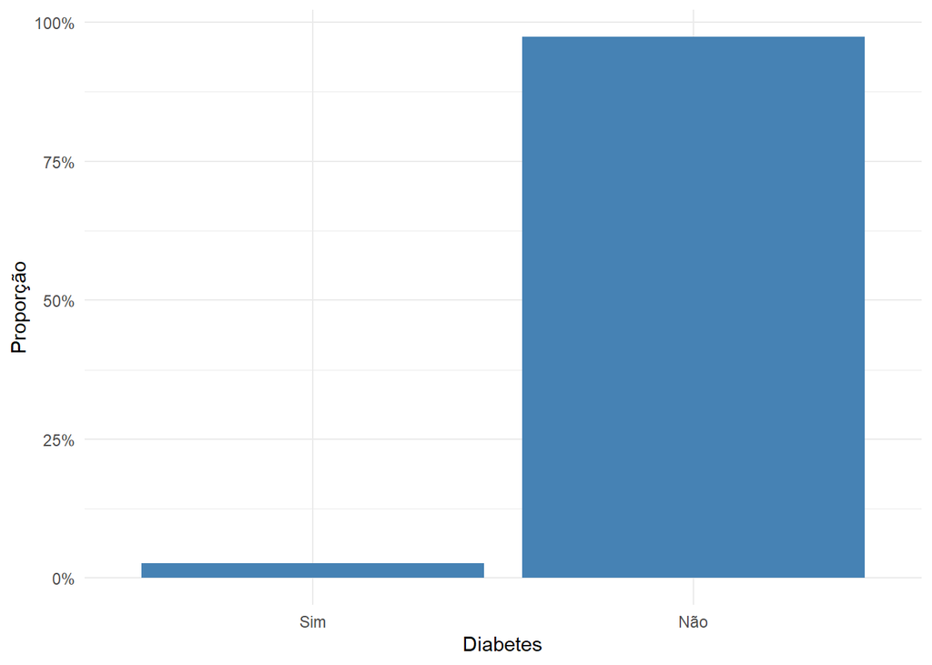

```r
ggplot(d_pns, aes(x = diabetes_auto)) +
geom_bar(aes(y = after_stat(prop), group = 1), fill = "steelblue") +
scale_y_continuous(labels = percent_format()) +
labs(x = "Diabetes", y = "Proporção") +
theme_minimal()
```

## 11 Observações Metodológicas

- A significância estatística é influenciada pelo grande tamanho amostral.
- O V de Cramer foi utilizado como principal métrica de interpretação.
- A imputação via árvore de decisão foi empregada exclusivamente para fins analíticos.